# Classification

# **Logistic regression**

An alternative might be to relate a function of 𝑃(𝑌=1|𝑋=𝑥), 𝑔(𝑃(𝑌=1|𝑋=𝑥)) say, to the linear predictor 𝛽0+𝛽1𝑥. This is the foundation of the broader class of generalised linear models. Under this framework, 𝑔() is referred to as the link function.

Logistic regression is one example of a generalised linear model which suits our requirements here. The link function is the logit function:𝑔(𝜇)=log(𝜇1−𝜇)The logit function takes values in [0,1] and transforms them to the range (−∞,∞).

Our logistic regression model is therefore of the form:log(𝑃(𝑌=1|𝑋=𝑥)1−𝑃(𝑌=1|𝑋=𝑥))=𝛽0+𝛽1𝑥The left hand side of this expression is commonly referred to as the log odds.

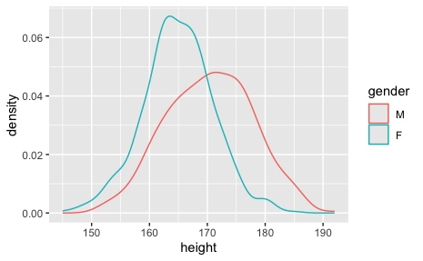

```r
mf_training %>%
  mutate(gender=factor(gender, labels=c("M","F"))) %>%
  ggplot() +
  geom_density(mapping=aes(x=height, color=gender))
```

- bionomial: log odds (probability)

```r
model_logreg <- glm(gender ~ height,
                    data=mf_training,
                    family=binomial)

summary(model_logreg)
```

```
Call:
glm(formula = gender ~ height, family = binomial, data = mf_training)

Coefficients:
            Estimate Std. Error z value Pr(>|z|)
(Intercept) 21.07065    1.87391   11.24   <2e-16 ***
height      -0.12329    0.01115  -11.06   <2e-16 ***
---
Signif. codes:  0 ‘***’ 0.001 ‘**’ 0.01 ‘*’ 0.05 ‘.’ 0.1 ‘ ’ 1

(Dispersion parameter for binomial family taken to be 1)

    Null deviance: 1346.0  on 999  degrees of freedom
Residual deviance: 1195.2  on 998  degrees of freedom
AIC: 1199.2

Number of Fisher Scoring iterations: 3
```

The R output indicates:log(𝑃(𝑌=1|𝑋=𝑥)1−𝑃(𝑌=1|𝑋=𝑥))=21.1−0.1𝑥

We often want to use a logistic regression model to make predictions for 𝑃(𝑌=1|𝑋=𝑥), for which we can rearrange the general model expression.log(𝑃(𝑌=1|𝑋=𝑥)1−𝑃(𝑌=1|𝑋=𝑥))=𝛽0+𝛽1𝑥⇒𝑃(𝑌=1|𝑋=𝑥)=11+exp(−(𝛽0+𝛽1𝑥))The expression on the right hand side is the logistic function, the inverse of the logit function, which is how logistic regression gets its name.

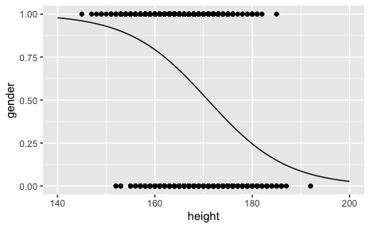

```r
mf_fit <- tibble(height=seq(140,200,length.out=100))

mf_fit$gender <- predict(model_logreg,
                         newdata=mf_fit,
                         type="resp")

ggplot(mapping=aes(y=gender, x=height)) +
  geom_point(data=mf_training) +
  geom_line(data=mf_fit)
```

log(𝑃(𝑌=1|𝑋=𝑥)1−𝑃(𝑌=1|𝑋=𝑥))=𝛽0+𝛽1𝑥𝑃(𝑌=1|𝑋=𝑥)=0.5⇒0=𝛽0+𝛽1𝑥⇒

𝑥=−𝛽0/𝛽1

```r
  db
```

```
[1] 171.0162
```

```r
db_logreg <- (-model_logreg$coefficients[[1]])/model_logreg$coefficients[[2]]
db_logreg
```

```
[1] 170.902
```

```r
mf_training$pred <- predict(model_logreg,type="resp")
mf_training$pred_gender <- if_else(mf_training$pred < 0.5, 0, 1)

table(predicted=mf_training$pred_gender,actual=mf_training$gender)
```

```
         actual
predicted   0   1
        0 204  99
        1 196 501
```

```r
sum(mf_training$pred_gender!=mf_training$gender)/nrow(mf_training)
```

```
[1] 0.295
```

- ?predict.glm
- resp: type => response variable (0/1) probability

```r
mf_test$pred <- predict(model_logreg,type="resp",newdata=mf_test)
mf_test$pred_gender <- if_else(mf_test$pred < 0.5, 0, 1)

table(predicted=mf_test$pred_gender,actual=mf_test$gender)
```

```
         actual
predicted   0   1
        0 228  96
        1 270 406
```

# **Classification in the case of more than two outcome categories**

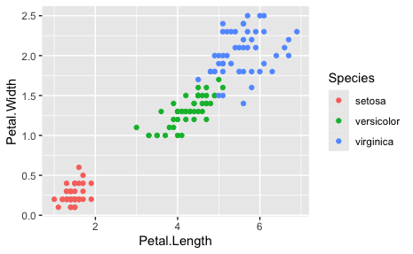

```r
data(iris)

ggplot(data=iris, mapping=aes(x=Petal.Length,
                              y=Petal.Width,
                              color=Species)) +
  geom_point()
```

```r
iris_simple <- iris %>%
  filter(Species == "virginica" | Species=="versicolor") %>%
  select(Species, Sepal.Length, Sepal.Width) %>%
  mutate(is_versicolor = if_else(Species == "versicolor", 1, 0),
         Species = droplevels(Species))

# note the drop levels command updates the factor levels
# to reflect it only contains entries for 2 Species

head(iris_simple)
```

|  | Species | Sepal.Length | Sepal.Width | is_versicolor |
| --- | --- | --- | --- | --- |
| 1 | versicolor | 7.0 | 3.2 | 1 |
| 2 | versicolor | 6.4 | 3.2 | 1 |
| 3 | versicolor | 6.9 | 3.1 | 1 |
| 4 | versicolor | 5.5 | 2.3 | 1 |
| 5 | versicolor | 6.5 | 2.8 | 1 |
| 6 | versicolor | 5.7 | 2.8 | 1 |

```r
logistic.model <- glm( is_versicolor ~ Sepal.Length + Sepal.Width,
                    data=iris_simple,family=binomial)

logistic.model.prediction <- if_else( predict(logistic.model,type='resp') > 0.5,
                                      'versicolor',
                                      'virginica')

table(predicted=logistic.model.prediction,actual=iris_simple$Species)
```

```
            actual
predicted    versicolor virginica
  versicolor         38        13
  virginica          12        37
```

```r
correct <- sum(logistic.model.prediction == iris_simple$Species)
correct
```

```
[1] 75
```

```r
incorrect <- sum(logistic.model.prediction != iris_simple$Species)
incorrect
```

```
[1] 25
```

```r
library(MASS)
select <- dplyr::select

lda.model <- lda(Species ~ Sepal.Length+Sepal.Width, data = iris_simple)

lda.model.prediction <- predict(lda.model)$class
table(predicted=lda.model.prediction,actual=iris_simple$Species)
```

```
            actual
predicted    versicolor virginica
  versicolor         38        13
  virginica          12        37
```

```r
table(LDA=lda.model.prediction,LR=logistic.model.prediction)
```

```
            LR
LDA          versicolor virginica
  versicolor         51         0
  virginica           0        49
```

```r
lda.model <- lda(Species ~ Sepal.Length+Sepal.Width, data = iris)

lda.model.prediction <- predict(lda.model)$class

table(predicted=lda.model.prediction,actual=iris$Species)
```

```
            actual
predicted    setosa versicolor virginica
  setosa         49          0         0
  versicolor      1         36        15
  virginica       0         14        35
```

```r
correct <- sum(lda.model.prediction == iris$Species)
correct
```

```
[1] 120
```

```r
incorrect <- sum(lda.model.prediction != iris$Species)
incorrect
```

```
[1] 30
```

```r
qda.model <- qda(Species ~ Sepal.Length+Sepal.Width, data = iris)

qda.model.prediction <- predict(qda.model)$class

table(predicted=qda.model.prediction,actual=iris$Species)
```

```
            actual
predicted    setosa versicolor virginica
  setosa         49          0         0
  versicolor      1         37        16
  virginica       0         13        34
```

```r
correct = sum(qda.model.prediction == iris$Species)
correct
```

```
[1] 120
```

```r
incorrect = sum(qda.model.prediction != iris$Species)
incorrect
```

```
[1] 30
```